# Aufgabenserie 10: Lineare Regression

Nicolas Stern

25.01.2019

# 1 Schätzen eines $y$-Wertes

Betrachten Sie den Datensatz $\textbf{mtcars}$. Modellieren Sie das Gewicht $\texttt{wt}$ der Autos als Funktion der Motorleistung $\texttt{hp}$.

Welches durchschnittliche Gewicht wird für ein Auto geschätzt, dessen Motor eine Leistung von $200$ PS aufweist?

*Lösungsweg:*

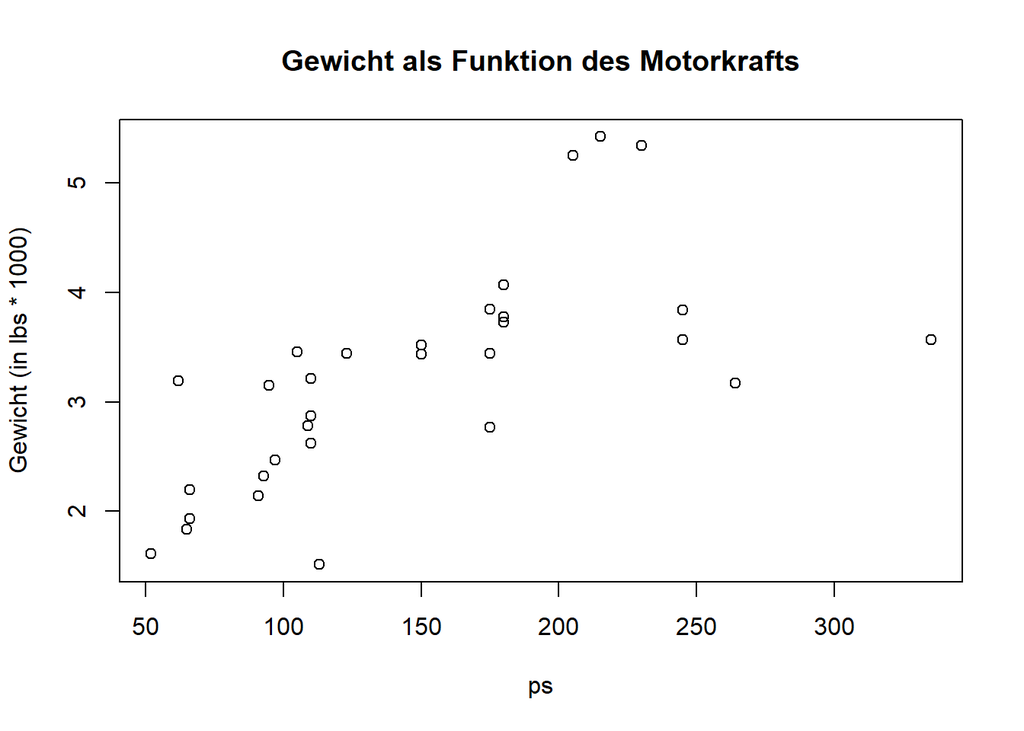

```r
# Daten zuerst plotten (scatterplot und qqplot) und betrachten. Prüfen, ob eine lineare Regression sinnvoll aussieht.

# scatterplot
plot(x = mtcars$hp,
     y=mtcars$wt,
     main = "Gewicht als Funktion des Motorkrafts",
     xlab = "ps",
     ylab = "Gewicht (in lbs * 1000)")
```

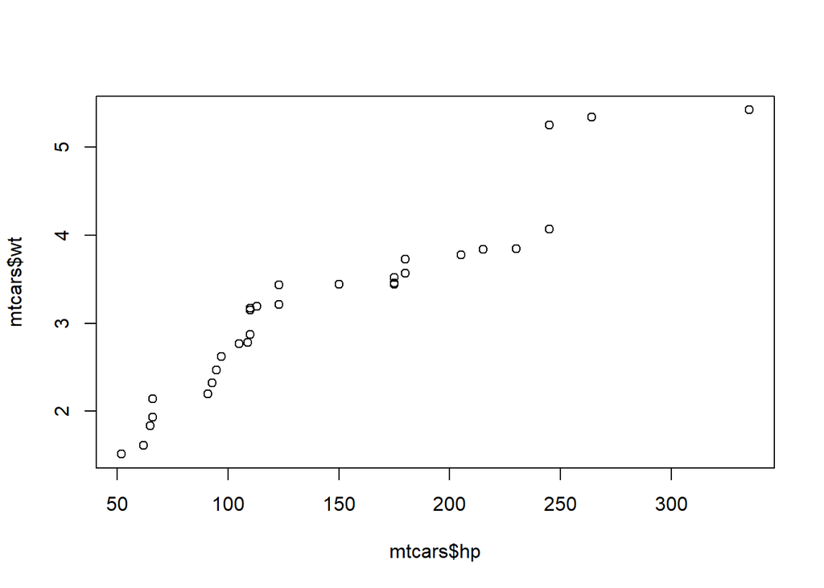

```r
# qqplot
qqplot(x = mtcars$hp, y=mtcars$wt)
```

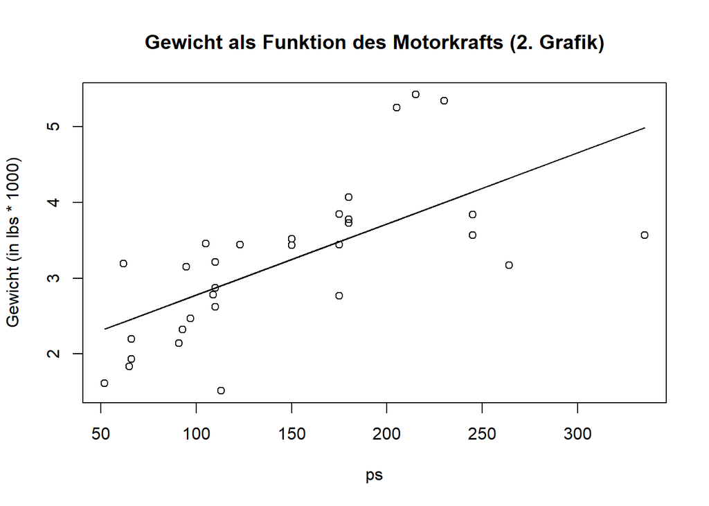

```r
# Versuch, eine passende lineare Regression zu modellieren:
# model populieren
lm.wt <- lm (wt~hp, data=mtcars)

# coeffs extrahieren:
coeffs <- coefficients(lm.wt)
steigung <- coeffs[2]
intercept <- coeffs[1]

# Daten und Linie des Modells zusammen plotten
x <- mtcars$hp
y <- mtcars$wt

plot(x = mtcars$hp,
     y=mtcars$wt,
     main = "Gewicht als Funktion des Motorkrafts (2. Grafik)",
     xlab = "ps",
     ylab = "Gewicht (in lbs * 1000)")
lines(x, intercept + x*steigung)
```

```r
# Berechung des erwarteten Gewichtes für ein Auto mit 200hp:
hp1  <- 200
est.wt1 <- intercept + steigung * hp1
est.wt1
```

```
## (Intercept)
##    3.718439
```

```r
# Dieselbe Berechnung mit der R-Funktion predict:
hp2 <- data.frame(hp=200)
est.wt2 <- predict(lm.wt, hp2)
est.wt2
```

```
##        1
## 3.718439
```

*Interpretation:*  
Zu beobachten ist eine statistische positive Korrelation zwischen Motorkraft und Gewicht der PWs aus mtcars. Die Korrelation ist deutlich, weist aber eine deutliche Streuung. Aus der Korrelation darf man schliessen, dass je stärker ein Motor ist, umso schwerer erwartet man das Fahrzeug.

# 2 Bestimmtheitsmass

Bestimmen Sie das Bestimmtheitsmass $r^2$ des linearen Modells zu $\textbf{mtcars}$.

*Lösungsweg:*

```r
r2 <- summary(lm.wt)$r.squared
```

Bestimmtheitsmass für das lineare Modell aus mtcars : 0.4339

# 3 Signifikanztest für $\beta_1$

Untersuchen Sie, ob zwischen den Grössen $\texttt{wt}$ und $\texttt{hp}$ aus $\textbf{mtcars}$ ein signifikanter Zusammenhang besteht.

*Lösungsweg:*

H$_0$ : $\beta_1$ = 0 : Es besteht kein lineares Zusammenhang zwischen x und y

H$_a$ : $\beta_1$ != 0 : Es besteht ein signifikantes Zusammenhang zwischen x und y

```r
summary(lm.wt)
```

```
##
## Call:
## lm(formula = wt ~ hp, data = mtcars)
##
## Residuals:
##      Min       1Q   Median       3Q      Max
## -1.41757 -0.53122 -0.02038  0.42536  1.56455
##
## Coefficients:
##             Estimate Std. Error t value Pr(>|t|)
## (Intercept) 1.838247   0.316520   5.808 2.39e-06 ***
## hp          0.009401   0.001960   4.796 4.15e-05 ***
## ---
## Signif. codes:  0 '***' 0.001 '**' 0.01 '*' 0.05 '.' 0.1 ' ' 1
##
## Residual standard error: 0.7483 on 30 degrees of freedom
## Multiple R-squared:  0.4339, Adjusted R-squared:  0.4151
## F-statistic:    23 on 1 and 30 DF,  p-value: 4.146e-05
```

p-Wert = 4.146 * $10^{-5}$

p-Wert ist sehr klein, so kann H$_0$ verworfen werden. Es besteht ein Zusammenhang zwischen x (Leistung) und y (Gewicht).

# 4 Konfidenzintervalle für $y$

Bestimmen Sie ein $95\%$-Konfidenzintervall für das durchschnittliche Gewicht bei einer Motorenleistung von 200 PS.

*Lösungsweg:*

```r
se.steigung <- summary(lm.wt)$coefficients[,2][2]
ME.steigung <- qnorm(0.975) * se.steigung
konfidenz.intervall <- steigung + c(-ME.steigung,ME.steigung)
```

# 5 Normalverteilte Residuen

Betrachten Sie das lineare Modell, welches das Gewicht eines Autos als Funktions des Motorenleistung modelliert. Erstellen Sie ein Normal-Wahrscheinlichkeits-Diagramm und testen Sie, ob die Residuen normalverteilt sind.

*Lösungsweg:*

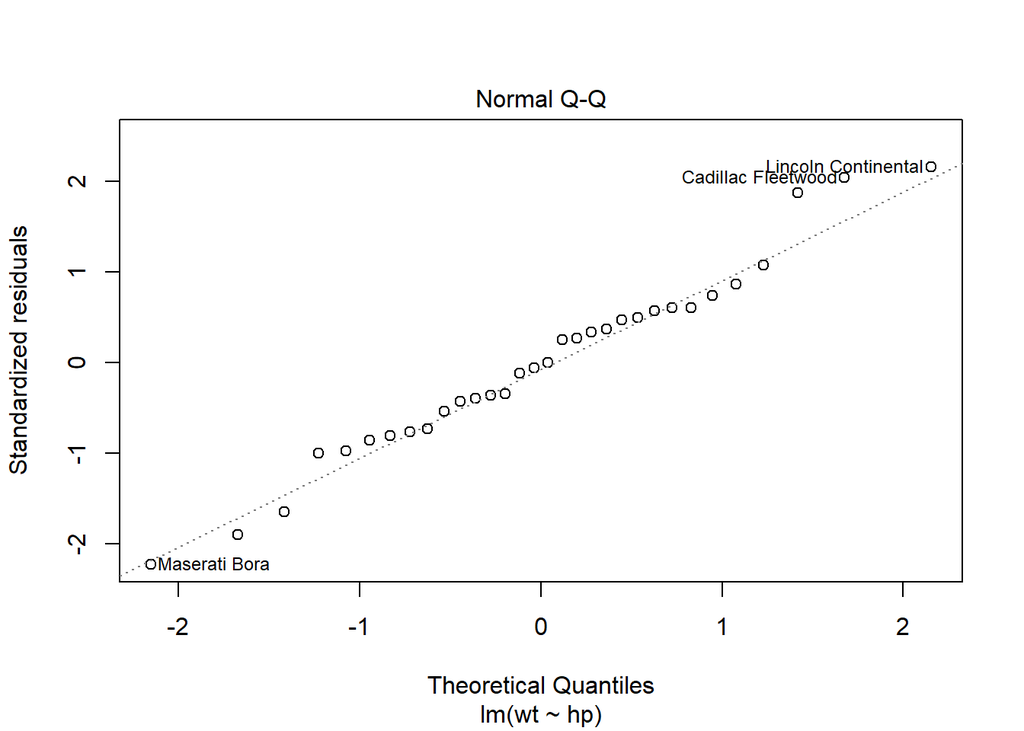

```r
plot(lm.wt, which=2)
```

Antwort: da die Residuen auf einer Gerade sind, darf man annehmen, sie seien normalverteilt.